# DP Notes

### Dynamic Programming Notes

Prepared by Zhikun Zhao

Prepared date: 3/30/2019

```python
import functools
import time
import sys
from IPython.display import Image
```

### Definition

Dynamic programming is a method for solving a complex problem by breaking it down into a collection of simpler subproblems, solving each of those subproblems just once, and storing their solutions. The next time the same subproblem occurs, instead of recomputing its solution, one simply looks up the previously computed solution, thereby saving computation time.

Dynamic Programming is mainly an optimization over plain recursion. Wherever we see a recursive solution that has repeated calls for same inputs, we can optimize it using Dynamic Programming. The idea is to simply store the results of subproblems, so that we do not have to re-comupute them when needed later. This simple optimization reduces time complexities from exponential to polynomial.

Common strategies in DP:

```
1. Memoization ensures that a method doesn't run for the same inputs more than once by keeping a record of the results for the given inputs (usually in a hash map)

2. Bottom-up: Going bottom-up is a way to avoid recursion, saving the memory cost that recursion incurs when it builds up the call stack.
```

### Example: Fibonacci

For example, if we write simple recursive solution for Fibonacci Numbers, we get exponential time complexity and if we optimize it by storing solutions of subproblems, time complexity reduces to linear.

The Fibonacci numbers are the numbers in the following integer sequence. 0, 1, 1, 2, 3, 5, 8, 13, 21, 34, 55, 89, 144, ……..

In mathematical terms, the sequence Fn of Fibonacci numbers is defined by the recurrence relation

```
Fn = Fn-1 + Fn-2
```

with seed values

```
F0 = 0 and F1 = 1.
```

```python
# Approach 1: Use Recursion

def fibonacci(num):
    if num < 2:
        return num
    return fibonacci(num - 1) + fibonacci(num - 2)
```

Function Call Structure:

```
                        fib(5)
                 /                 \
           fib(4)                  fib(3)
         /        \              /       \
     fib(3)       fib(2)         fib(2)   fib(1)
    /    \        /    \        /      \
  fib(2) fib(1) fib(1) fib(0)  fib(0) fib(1)
/     \
fib(1) fib(0)
```

Time Complexity: T(n) = T(n-1) + T(n-2) which is exponential.

```python
start_time = time.perf_counter()
print('result is: {}'.format(str(fibonacci(35))))
end_time = time.perf_counter()
run_time = end_time - start_time
print('Total Runtime is: {} sec.'.format(str(run_time)))
```

```
result is: 9227465
Total Runtime is: 4.439817544014659 sec.
```

```python
# Approach 2: DP Bottom-up
def fibonacci(n):
    # Taking 1st two fibonacci nubers as 0 and 1
    FibArray = [0, 1]

    while len(FibArray) < n + 1:
        FibArray.append(0)

    for i in range(2, n+1):
        FibArray[i] = FibArray[i - 2] + FibArray[i - 1]

    return FibArray[n]
```

```python
start_time = time.perf_counter()
print('result is: {}'.format(str(fibonacci(35))))
end_time = time.perf_counter()
run_time = end_time - start_time
print('Total Runtime is: {} sec.'.format(str(run_time)))
```

```
result is: 9227465
Total Runtime is: 0.0005531439674086869 sec.
```

```python
# Approach 2: DP Bottom-up Space Optimized
def fibonacci(n):
    a = 0
    b = 1
    if n < 0:
        print("Incorrect input")
    elif n == 0:
        return a
    elif n == 1:
        return b
    else:
        for i in range(2,n+1):
            c = a + b
            a = b
            b = c
        return b
```

```python
start_time = time.perf_counter()
print('result is: {}'.format(str(fibonacci(35))))
end_time = time.perf_counter()
run_time = end_time - start_time
print('Total Runtime is: {} sec.'.format(str(run_time)))
```

```
result is: 9227465
Total Runtime is: 0.0002797759952954948 sec.
```

```python
# Approach 2: DP Memoization using function decorator
def count_calls(func):
    @functools.wraps(func)
    def wrapper_count_calls(*args,**kwargs):
        wrapper_count_calls.num_calls += 1
        print(f"Call {wrapper_count_calls.num_calls} of {func.__name__!r}")
        return func(*args, **kwargs)
    wrapper_count_calls.num_calls = 0
    return wrapper_count_calls

def cache(func):
    """Keep a cache of previous function calls"""
    @functools.wraps(func)
    def wrapper_cache(*args, **kwargs):
        cache_key = args + tuple(kwargs.items())
        if cache_key not in wrapper_cache.cache:
            wrapper_cache.cache[cache_key] = func(*args, **kwargs)
        return wrapper_cache.cache[cache_key]
    wrapper_cache.cache = dict()
    return wrapper_cache
```

```python
@cache
def fibonacci(num):
    if num < 2:
        return num
    return fibonacci(num - 1) + fibonacci(num - 2)

start_time = time.perf_counter()
print('result is: {}'.format(str(fibonacci(35))))
end_time = time.perf_counter()
run_time = end_time - start_time
print('Total Runtime is: {} sec.'.format(str(run_time)))
```

```
result is: 9227465
Total Runtime is: 0.0004079090431332588 sec.
```

```python
@count_calls
def fibonacci(num):
    if num < 2:
        return num
    return fibonacci(num - 1) + fibonacci(num - 2)
fibonacci(5)
```

```
Call 1 of 'fibonacci'
Call 2 of 'fibonacci'
Call 3 of 'fibonacci'
Call 4 of 'fibonacci'
Call 5 of 'fibonacci'
Call 6 of 'fibonacci'
Call 7 of 'fibonacci'
Call 8 of 'fibonacci'
Call 9 of 'fibonacci'
Call 10 of 'fibonacci'
Call 11 of 'fibonacci'
Call 12 of 'fibonacci'
Call 13 of 'fibonacci'
Call 14 of 'fibonacci'
Call 15 of 'fibonacci'
```

```
5
```

```python
@cache
@count_calls
def fibonacci(num):
    if num < 2:
        return num
    return fibonacci(num - 1) + fibonacci(num - 2)
fibonacci(5)
```

```
Call 1 of 'fibonacci'
Call 2 of 'fibonacci'
Call 3 of 'fibonacci'
Call 4 of 'fibonacci'
Call 5 of 'fibonacci'
Call 6 of 'fibonacci'
```

```
5
```

# Longest Common Subsequence

Definition 11.1 The Longest Common Subsequence (LCS) problem is as follows. We are given two strings: string S of length n, and string T of length m. Our goal is to produce their longest common subsequence: the longest sequence of characters that appear left-to-right (but not necessarily in a contiguous block) in both strings

LCS Problem Statement: Given two sequences, find the length of longest subsequence present in both of them. A subsequence is a sequence that appears in the same relative order, but not necessarily contiguous. For example, “abc”, “abg”, “bdf”, “aeg”, ‘”acefg”, .. etc are subsequences of “abcdefg”. So a string of length n has 2^n different possible subsequences.

It is a classic computer science problem, the basis of diff (a file comparison program that outputs the differences between two files), and has applications in bioinformatics.

Examples:

LCS for input Sequences “ABCDGH” and “AEDFHR” is “ADH” of length 3.

LCS for input Sequences “AGGTAB” and “GXTXAYB” is “GTAB” of length 4.

```python
# Method 1: Recursion
def lcs(X, Y, m, n):
    if m == 0 or n == 0:
        return 0;
    elif X[m-1] == Y[n-1]:
        return 1 + lcs(X, Y, m-1, n-1);
    else:
        return max(lcs(X, Y, m, n-1), lcs(X, Y, m-1, n));

start_time = time.perf_counter()
X = "AGGTABAFDLDG"
Y = "GXTXAYBGDAFLSHFSH"
print("Length of LCS is: ", lcs(X , Y, len(X), len(Y)))
end_time = time.perf_counter()
run_time = end_time - start_time
print('Total Runtime is: {} sec.'.format(str(run_time)))
```

```
Length of LCS is:  7
Total Runtime is: 2.626061539980583 sec.
```

Time complexity of the above naive recursive approach is O(2^n) in worst case and worst case happens when all characters of X and Y mismatch i.e., length of LCS is 0.

```
                        lcs("AXYT", "AYZX")
                  /                            \
      lcs("AXY", "AYZX")                        lcs("AXYT", "AYZ")
     /                \                         /
 lcs("AX", "AYZX")   lcs("AXY", "AYZ")        lcs("AXY", "AYZ")
     /
 lcs("AXYT", "AY")
```

```python
# Method 2: bottom-up
def lcs(X , Y):
    # find the length of the strings
    m = len(X)
    n = len(Y)

    # declaring the array for storing the dp values
    L = [[None]*(n+1) for i in range(m+1)]

    """Following steps build L[m+1][n+1] in bottom up fashion
    Note: L[i][j] contains length of LCS of X[0..i-1]
    and Y[0..j-1]"""
    for i in range(m+1):
        for j in range(n+1):
            if i == 0 or j == 0 :
                L[i][j] = 0
            elif X[i-1] == Y[j-1]:
                L[i][j] = L[i-1][j-1]+1
            else:
                L[i][j] = max(L[i-1][j] , L[i][j-1])

    # L[m][n] contains the length of LCS of X[0..n-1] & Y[0..m-1]
    return L[m][n]

start_time = time.perf_counter()
X = "AGGTABAFDLDG"
Y = "GXTXAYBGDAFLSHFSH"
print("Length of LCS is: ", lcs(X , Y))
end_time = time.perf_counter()
run_time = end_time - start_time
print('Total Runtime is: {} sec.'.format(str(run_time)))
```

```
Length of LCS is:  7
Total Runtime is: 0.0004777880385518074 sec.
```

```python
# Method 2: Memoization
@cache
def lcs(X, Y, m, n):
    if m == 0 or n == 0:
        return 0;
    elif X[m-1] == Y[n-1]:
        return 1 + lcs(X, Y, m-1, n-1);
    else:
        return max(lcs(X, Y, m, n-1), lcs(X, Y, m-1, n));

start_time = time.perf_counter()
X = "AGGTABAFDLDG"
Y = "GXTXAYBGDAFLSHFSH"
print("Length of LCS is: ", lcs(X , Y, len(X), len(Y)))
end_time = time.perf_counter()
run_time = end_time - start_time
print('Total Runtime is: {} sec.'.format(str(run_time)))
```

```
Length of LCS is:  7
Total Runtime is: 0.0009142819908447564 sec.
```

### 221. Maximal Square

Given a 2D binary matrix filled with 0's and 1's, find the largest square containing only 1's and return its area.

Example:

Input:

1 0 1 0 0

1 0 1 1 1

1 1 1 1 1

1 0 0 1 0

Output: 4

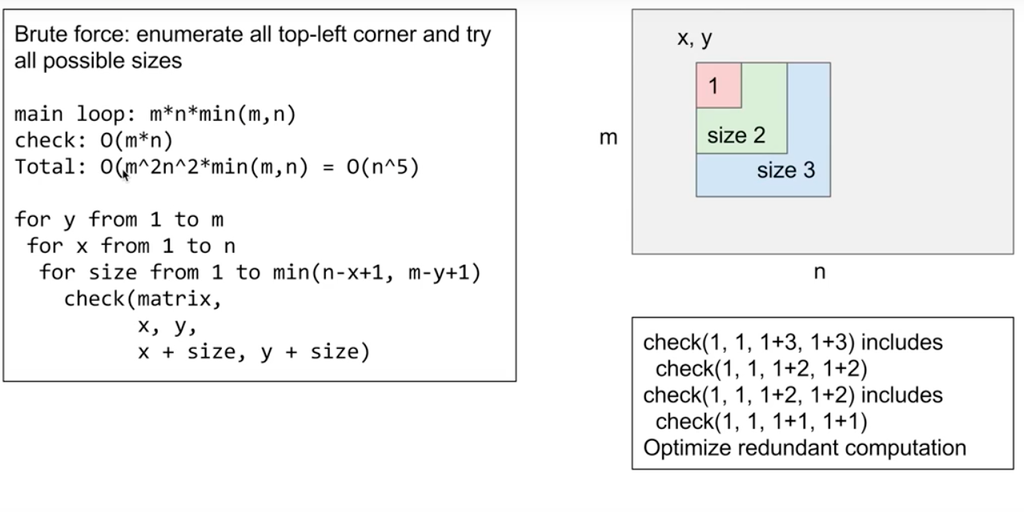

```python
Image(filename='dp_1.png',height=650, width=650)
```

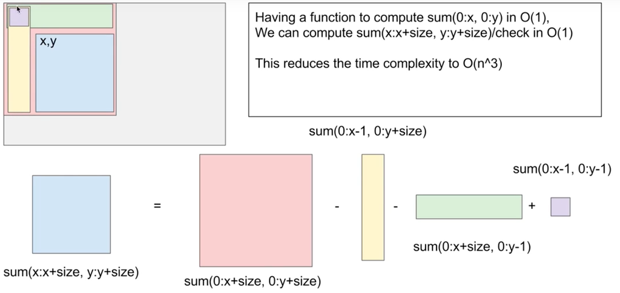

```python
Image(filename='dp_2.png',height=750, width=750)
```

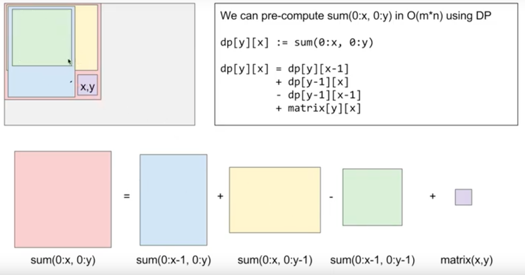

```python
Image(filename='dp_3.png',height=750, width=750)
```

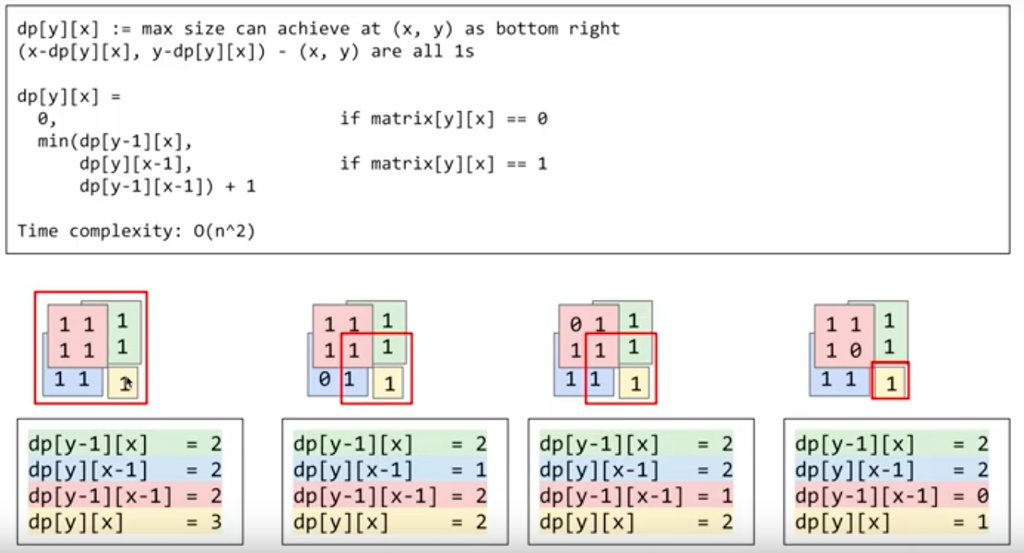

```python
Image(filename='dp_4.png',height=750, width=750)
```

```python
def maximalSquare(matrix):
    if not matrix:
        return 0

    m = len(matrix)
    n = len(matrix[0])

    dp = [[0 for i in range(n)] for j in range(m)]

    res = 0

    for i in range(m):
        for j in range(n):
            dp[i][j] = matrix[i][j]
            if i==0 or j==0:
                dp[i][j] = matrix[i][j] - 0
            elif matrix[i][j] == 1:
                dp[i][j] = min(dp[i][j-1], dp[i-1][j], dp[i-1][j-1])+1
            res = max(res, dp[i][j] * dp[i][j])
    return res

matrix = [[1,0,1,0,0],[1,0,1,1,1],[1,1,1,1,1],[1,0,0,1,0]]
maximalSquare(matrix)
```

```
4
```

### Knapsack Problem:

Given weights and values of n items, put these items in a knapsack of capacity W to get the maximum total value in the knapsack.

In other words, given two integer arrays val[0..n-1] and wt[0..n-1] which represent values and weights associated with n items respectively. Also given an integer W which represents knapsack capacity, find out the maximum value subset of val[] such that sum of the weights of this subset is smaller than or equal to W. You cannot break an item, either pick the complete item, or don’t pick it (0-1 property).

To consider all subsets of items, there can be two cases for every item: (1) the item is included in the optimal subset, (2) not included in the optimal set. Therefore, the maximum value that can be obtained from n items is max of following two values.

```
1) Maximum value obtained by n-1 items and W weight (excluding nth item).
2) Value of nth item plus maximum value obtained by n-1 items and W minus weight of the nth item (including nth item).
```

If weight of nth item is greater than W, then the nth item cannot be included and case 1 is the only possibility.

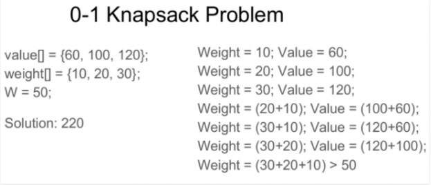

```python
Image(filename='dp_5.png',height=600, width=600)
```

```python
def knapSack(v, w, n, W):
    # base case: Negative capacity
    if (W < 0):
        return float('-inf')

    # base case: no items left or capacity becomes 0
    if (n < 0 or W == 0):
        return 0

    # Case 1. include current item n in knapSack (v[n]) and recurse for
    # remaining items (n - 1) with decreased capacity (W - w[n])
    include = v[n] + knapSack(v, w, n - 1, W - w[n])

    #Case 2. exclude current item n from knapSack and recurse for
    # remaining items (n - 1)
    exclude = knapSack(v, w, n - 1, W)

    # return maximum value we get by including or excluding current item
    return max(include, exclude)

# Input: set of items each with a weight and a value
v = [20, 5, 10, 40, 15, 25, 20, 5, 10, 40, 15, 25, 20, 5, 10, 40, 15, 25, 20, 5, 10, 40, 15, 25]
w = [1, 2,  3,  8,  7, 4, 1, 2,  3,  8,  7, 4, 1, 2,  3,  8,  7, 4, 1, 2,  3,  8,  7, 4]

# Knapsack capacity
W = 40

# number of items
n = len(v)
start_time = time.perf_counter()
knapSack(v, w, n - 1, W)
end_time = time.perf_counter()
run_time = end_time - start_time
print('Total Runtime is: {} sec.'.format(str(run_time)))
```

```
Total Runtime is: 3.117636944982223 sec.
```

```python
def knapSack(v, w, n, W, d):
    # base case: Negative capacity
    if (W < 0):
        return float('-inf')

    # base case: no items left or capacity becomes 0
    if (n < 0 or W == 0):
        return 0

    # construct a unique map key from dynamic elements of the input
    key = str(n) + '|' + str(W)

    if key not in d:
        # Case 1. include current item n in knapSack (v[n]) and recurse for
        # remaining items (n - 1) with decreased capacity (W - w[n])
        include = v[n] + knapSack(v, w, n - 1, W - w[n], d)

        #Case 2. exclude current item n from knapSack and recurse for
        # remaining items (n - 1)
        exclude = knapSack(v, w, n - 1, W, d)

        d[key] = max(include, exclude)
    return d[key]

# Input: set of items each with a weight and a value
v = [20, 5, 10, 40, 15, 25, 20, 5, 10, 40, 15, 25, 20, 5, 10, 40, 15, 25, 20, 5, 10, 40, 15, 25]
w = [1, 2,  3,  8,  7, 4, 1, 2,  3,  8,  7, 4, 1, 2,  3,  8,  7, 4, 1, 2,  3,  8,  7, 4]

# Knapsack capacity
W = 40

# number of items
n = len(v)
d = {}
start_time = time.perf_counter()
knapSack(v, w, n - 1, W, d)
end_time = time.perf_counter()
run_time = end_time - start_time
print('Total Runtime is: {} sec.'.format(str(run_time)))
```

```
Total Runtime is: 0.002111662004608661 sec.
```

# Matrix Chain Multiplication Problem

Given a sequence of matrices, find the most efficient way to multiply these matrices together. The problem is not actually to perform the multiplications, but merely to decide in which order to perform the multiplications.

We have many options to multiply a chain of matrices because matrix multiplication is associative. In other words, no matter how we parenthesize the product, the result will be the same. For example, if we had four matrices A, B, C, and D, we would have:

(ABC)D = (AB)(CD) = A(BCD) = ....

However, the order in which we parenthesize the product affects the number of simple arithmetic operations needed to compute the product, or the efficiency. For example, suppose A is a 10 × 30 matrix, B is a 30 × 5 matrix, and C is a 5 × 60 matrix. Then:

```
(AB)C = (10×30×5) + (10×5×60) = 1500 + 3000 = 4500 operations
A(BC) = (30×5×60) + (10×30×60) = 9000 + 18000 = 27000 operations
```

Given an array p[] which represents the chain of matrices such that the ith matrix Ai is of dimension p[i-1] x p[i]. We need to write a function MatrixChainOrder() that should return the minimum number of multiplications needed to multiply the chain.

Input: p[] = {40, 20, 30, 10, 30}  
Output: 26000  
There are 4 matrices of dimensions 40x20, 20x30, 30x10 and 10x30. Let the input 4 matrices be A, B, C and D. The minimum number of multiplications are obtained by putting parenthesis in following way

```
  (A(BC))D --> 20*30*10 + 40*20*10 + 40*10*30
```

Input: p[] = {10, 20, 30, 40, 30} Output: 30000 There are 4 matrices of dimensions 10x20, 20x30, 30x40 and 40x30. Let the input 4 matrices be A, B, C and D. The minimum number of multiplications are obtained by putting parenthesis in following way

```
  ((AB)C)D --> 10*20*30 + 10*30*40 + 10*40*30
```

```python
# Method 1: Recursion
import sys
# Matrix A[i] has dimension p[i-1] x p[i] for i = 1..n
def MatrixChainOrder(p, i, j):
    if i == j:
        return 0

    _min = sys.maxsize

    for k in range(i, j):

        count = (MatrixChainOrder(p, i, k)
             + MatrixChainOrder(p, k+1, j)
                   + p[i-1] * p[k] * p[j])

        if count < _min:
            _min = count

    return _min

arr = [40, 20, 30, 10, 30, 40, 20, 30, 10, 30, 40, 20, 30, 10, 30, 40, 20]
n = len(arr);

start_time = time.perf_counter()
print("Minimum number of multiplications is ", MatrixChainOrder(arr, 1, n-1))
end_time = time.perf_counter()
run_time = end_time - start_time
print('Total Runtime is: {} sec.'.format(str(run_time)))
```

```
Minimum number of multiplications is  101000
Total Runtime is: 6.737640420964453 sec.
```

Time complexity of the above naive recursive approach is exponential. It should be noted that the above function computes the same subproblems again and again.

See the following recursion tree for a matrix chain of size 4. The function MatrixChainOrder(p, 3, 4) is called two times. We can see that there are many subproblems being called more than once.

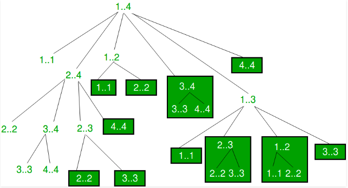

```python
Image(filename='dp_6.png',height=750, width=750)
```

```python
# Method 2: bottom-up
def MatrixChainOrder(p, n):
    m = [[0 for x in range(n)] for x in range(n)]

    # m[i,j] = Minimum number of scalar multiplications needed
    # to compute the matrix A[i]A[i+1]...A[j] = A[i..j] where
    # dimension of A[i] is p[i-1] x p[i]

    # cost is zero when multiplying one matrix.
    for i in range(1, n):
        m[i][i] = 0

    # L is chain length.
    for L in range(2, n):
        for i in range(1, n-L+1):
            j = i+L-1
            m[i][j] = sys.maxsize
            for k in range(i, j):

                q = m[i][k] + m[k+1][j] + p[i-1]*p[k]*p[j]
                if q < m[i][j]:
                    m[i][j] = q
    return m[1][n-1]

arr = [40, 20, 30, 10, 30, 40, 20, 30, 10, 30, 40, 20, 30, 10, 30, 40, 20]
size = len(arr)

start_time = time.perf_counter()
print("Minimum number of multiplications is ", MatrixChainOrder(arr, size))
end_time = time.perf_counter()
run_time = end_time - start_time
print('Total Runtime is: {} sec.'.format(str(run_time)))
```

```
Minimum number of multiplications is  101000
Total Runtime is: 0.0007859760080464184 sec.
```

# Reference

1. GeeksforGeeks
2. LeetCode
3. 花花酱 LeetCode